# Installation of Matplotlib

```python
!pip install matplotlib
```

# Matplotlib Version

```python
import matplotlib

print(matplotlib.__version__)
```

```
3.2.2
```

# Pyplot

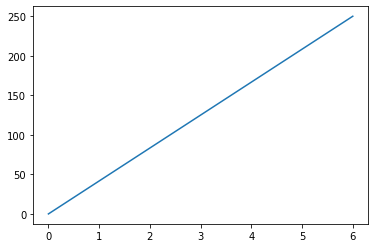

```python
import matplotlib.pyplot as plt
import numpy as np
xpoints = np.array([0,6])
ypoints = np.array([0,250])
plt.plot(xpoints,ypoints)
plt.show()
```

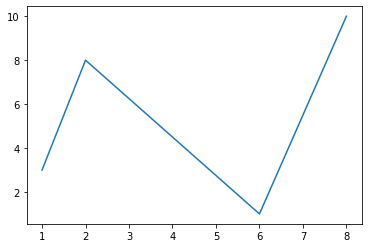

```python
import matplotlib.pyplot as plt
import numpy as np

xpoints = np.array([1, 2, 6, 8])
ypoints = np.array([3, 8, 1, 10])

plt.plot(xpoints, ypoints)
plt.show()
```

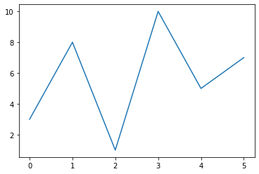

```python
import matplotlib.pyplot as plt
import numpy as np

ypoints = np.array([3, 8, 1, 10, 5, 7])

plt.plot(ypoints)
plt.show()
```

# Matplotlib Markers

`You can use the keyword argument marker to emphasize each point with a specified marker:`

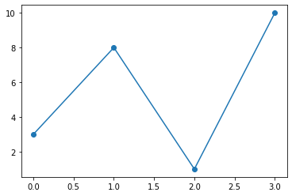

```python
import matplotlib.pyplot as plt
import numpy as np

ypoints = np.array([3, 8, 1, 10])

plt.plot(ypoints, marker = 'o')
plt.show()
```

[Marker Reference](https://www.w3schools.com/python/matplotlib_markers.asp)

`You can use the keyword argument markersize or the shorter ms to set the size of the markers, markeredgecolor or the shorter mec to set the color of the edge of the markers, markerfacecolor or the shorter mfc to set the color inside the edge of the markers:`

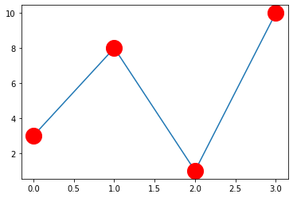

```python
import matplotlib.pyplot as plt
import numpy as np

ypoints = np.array([3, 8, 1, 10])

plt.plot(ypoints, marker = 'o', ms = 20, mec = 'r', mfc = 'r')
plt.show()
```

# Line

`You can use the keyword argument linestyle, or shorter ls, to change the style of the plotted line:`

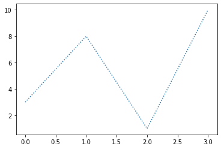

```python
import matplotlib.pyplot as plt
import numpy as np

ypoints = np.array([3, 8, 1, 10])

plt.plot(ypoints, linestyle = 'dotted')
plt.show()
```

[Line Styles](https://www.w3schools.com/python/matplotlib_line.asp)

`You can use the keyword argument color or the shorter c to set the color of the line, linewidth or the shorter lw to change the width of the line.`

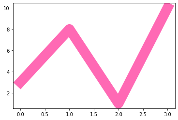

```python
import matplotlib.pyplot as plt
import numpy as np

ypoints = np.array([3, 8, 1, 10])

plt.plot(ypoints, c = 'hotpink', linewidth = '20.5')
plt.show()
```

**Multiple Lines**

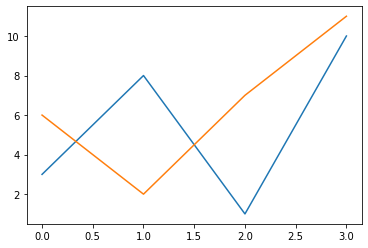

```python
import matplotlib.pyplot as plt
import numpy as np

x1 = np.array([0, 1, 2, 3])
y1 = np.array([3, 8, 1, 10])
x2 = np.array([0, 1, 2, 3])
y2 = np.array([6, 2, 7, 11])

plt.plot(x1, y1, x2, y2)
plt.show()
```

# Labels and Title

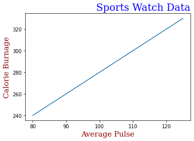

```python
import numpy as np
import matplotlib.pyplot as plt

x = np.array([80, 85, 90, 95, 100, 105, 110, 115, 120, 125])
y = np.array([240, 250, 260, 270, 280, 290, 300, 310, 320, 330])

font1 = {'family':'serif','color':'blue','size':20}
font2 = {'family':'serif','color':'darkred','size':15}

#Legal values are: 'left', 'right', and 'center'. Default value is 'center'.
plt.title("Sports Watch Data", fontdict = font1, loc = 'right')

plt.xlabel("Average Pulse", fontdict = font2)
plt.ylabel("Calorie Burnage", fontdict = font2)

plt.plot(x, y)
plt.show()
```

# Grid Line

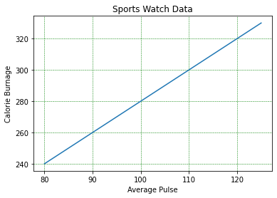

```python
import numpy as np
import matplotlib.pyplot as plt

x = np.array([80, 85, 90, 95, 100, 105, 110, 115, 120, 125])
y = np.array([240, 250, 260, 270, 280, 290, 300, 310, 320, 330])

plt.title("Sports Watch Data")
plt.xlabel("Average Pulse")
plt.ylabel("Calorie Burnage")

plt.plot(x, y)

# plt.grid()
# plt.grid(axis = 'x')

plt.grid(color = 'green', linestyle = '--', linewidth = 0.5)

plt.show()
```

# Subplots

`The subplots() function takes three arguments that describes the layout of the figure.`

`The third argument represents the index of the current plot.`

`plt.subplot(1, 2, 1); the figure has 1 row, 2 columns, and this plot is the first plot.`

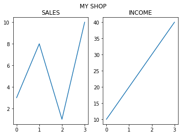

```python
import matplotlib.pyplot as plt
import numpy as np

#plot 1:
x = np.array([0, 1, 2, 3])
y = np.array([3, 8, 1, 10])

plt.subplot(1, 2, 1)
plt.plot(x,y)
plt.title("SALES")

#plot 2:
x = np.array([0, 1, 2, 3])
y = np.array([10, 20, 30, 40])

plt.subplot(1, 2, 2)
plt.plot(x,y)
plt.title("INCOME")

plt.suptitle("MY SHOP")
plt.show()
```

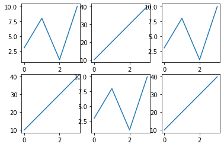

```python
import matplotlib.pyplot as plt
import numpy as np

x = np.array([0, 1, 2, 3])
y = np.array([3, 8, 1, 10])

plt.subplot(2, 3, 1)
plt.plot(x,y)

x = np.array([0, 1, 2, 3])
y = np.array([10, 20, 30, 40])

plt.subplot(2, 3, 2)
plt.plot(x,y)

x = np.array([0, 1, 2, 3])
y = np.array([3, 8, 1, 10])

plt.subplot(2, 3, 3)
plt.plot(x,y)

x = np.array([0, 1, 2, 3])
y = np.array([10, 20, 30, 40])

plt.subplot(2, 3, 4)
plt.plot(x,y)

x = np.array([0, 1, 2, 3])
y = np.array([3, 8, 1, 10])

plt.subplot(2, 3, 5)
plt.plot(x,y)

x = np.array([0, 1, 2, 3])
y = np.array([10, 20, 30, 40])

plt.subplot(2, 3, 6)
plt.plot(x,y)

plt.show()
```

# Scatter

`The scatter() function plots one dot for each observation. It needs two arrays of the same length, one for the values of the x-axis, and one for values on the y-axis:`

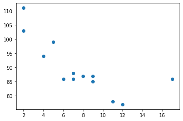

```python
import matplotlib.pyplot as plt
import numpy as np

x = np.array([5,7,8,7,2,17,2,9,4,11,12,9,6])
y = np.array([99,86,87,88,111,86,103,87,94,78,77,85,86])

plt.scatter(x, y)
plt.show()
```

**Compare Plots**

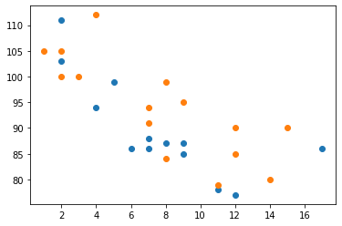

```python
import matplotlib.pyplot as plt
import numpy as np

#day one, the age and speed of 13 cars:
x = np.array([5,7,8,7,2,17,2,9,4,11,12,9,6])
y = np.array([99,86,87,88,111,86,103,87,94,78,77,85,86])
plt.scatter(x, y)

#day two, the age and speed of 15 cars:
x = np.array([2,2,8,1,15,8,12,9,7,3,11,4,7,14,12])
y = np.array([100,105,84,105,90,99,90,95,94,100,79,112,91,80,85])
plt.scatter(x, y)

plt.show()
```

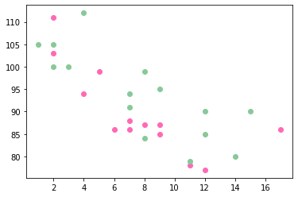

```python
import matplotlib.pyplot as plt
import numpy as np

x = np.array([5,7,8,7,2,17,2,9,4,11,12,9,6])
y = np.array([99,86,87,88,111,86,103,87,94,78,77,85,86])
plt.scatter(x, y, color = 'hotpink')

x = np.array([2,2,8,1,15,8,12,9,7,3,11,4,7,14,12])
y = np.array([100,105,84,105,90,99,90,95,94,100,79,112,91,80,85])
plt.scatter(x, y, color = '#88c999')

plt.show()
```

**Color Each Dot**

`colors = np.array(["red","green","blue","yellow","pink","black","orange","purple","beige","brown","gray","cyan","magenta"])`

`plt.scatter(x, y, c=colors)`

**ColorMap**

`This colormap is called 'viridis' and as you can see it ranges from 0, which is a purple color, and up to 100, which is a yellow color.`

`The colormap in the drawing by including the plt.colorbar() statement.`

`Change the size of the dots with the s argument.`

`Adjust the transparency of the dots with the alpha argument.`

[Color Map](https://www.w3schools.com/python/matplotlib_scatter.asp)

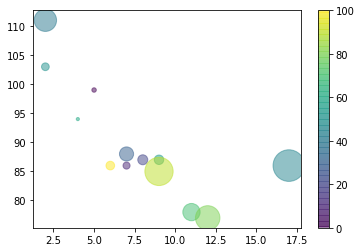

```python
import matplotlib.pyplot as plt
import numpy as np

x = np.array([5,7,8,7,2,17,2,9,4,11,12,9,6])
y = np.array([99,86,87,88,111,86,103,87,94,78,77,85,86])
colors = np.array([0, 10, 20, 30, 40, 45, 50, 55, 60, 70, 80, 90, 100])
sizes = np.array([20,50,100,200,500,1000,60,90,10,300,600,800,75])

plt.scatter(x, y, c=colors, s=sizes, alpha=0.5, cmap='viridis')

plt.colorbar()

plt.show()
```

# Bars

`The bar() takes the keyword argument width to set the width of the bars. The default width value is 0.8`

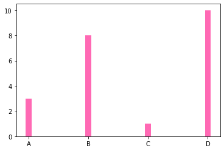

```python
import matplotlib.pyplot as plt
import numpy as np

x = np.array(["A", "B", "C", "D"])
y = np.array([3, 8, 1, 10])

#plt.bar(x,y)
#plt.bar(x, y, color = "red") # Bar Color
plt.bar(x, y, width = 0.1, color = "hotpink") # Bar Width.

plt.show()
```

`The bars to be displayed horizontally instead of vertically, use the barh() function. The barh() takes the keyword argument height to set the height of the bars. The default width value is 0.8`

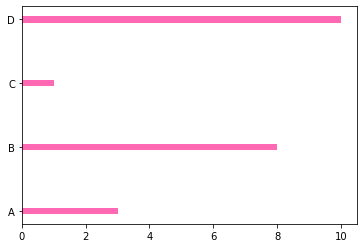

```python
import matplotlib.pyplot as plt
import numpy as np

x = np.array(["A", "B", "C", "D"])
y = np.array([3, 8, 1, 10])

#plt.barh(x, y) # Horizontal Bars
#plt.barh(x, y, color = "red") # Bar Color
plt.barh(x, y, height = 0.1, color = "hotpink")

plt.show()
```

# Histograms

`A histogram is a graph showing frequency distributions.It is a graph showing the number of observations within each given interval.`

`Use the random.normal() method to get a Normal Data Distribution.`

`It has three parameters:`

`loc - (Mean) where the peak of the bell exists.`

`scale - (Standard Deviation) how flat the graph distribution should be.`

`size - The shape of the returned array.`

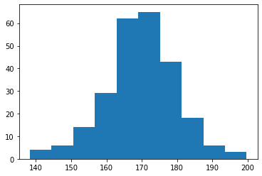

```python
import matplotlib.pyplot as plt
import numpy as np

x = np.random.normal(170, 10, 250)

plt.hist(x)
plt.show()
```

# Pie Charts

`use the pie() function to draw pie charts:`

`By default the plotting of the first wedge starts from the x-axis and move counterclockwise.The value divided by the sum of all values: x/sum(x).`

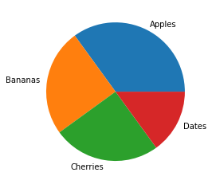

```python
import matplotlib.pyplot as plt
import numpy as np

y = np.array([35, 25, 25, 15])
mylabels = ["Apples", "Bananas", "Cherries", "Dates"]

plt.pie(y, labels = mylabels)
plt.show()
```

The default **start angle** is at the x-axis, but you can change the start angle.Default angle is 0.

**explode parameter**,Each value represents how far from the center each wedge is displayed.Pull the "Apples" wedge 0.2 from the center of the pie.

Add a **shadow** to the pie chart by setting the shadows parameter to True

The **colors** parameter, if specified, must be an array with one value for each wedge. 'r' - Red 'g' - Green 'b' - Blue 'c' - Cyan 'm' - Magenta 'y' - Yellow 'k' - Black 'w' - White

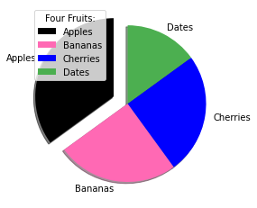

```python
import matplotlib.pyplot as plt
import numpy as np

y = np.array([35, 25, 25, 15])
mylabels = ["Apples", "Bananas", "Cherries", "Dates"]
mycolors = ["black", "hotpink", "b", "#4CAF50"]
myexplode = [0.2, 0, 0, 0]

plt.pie(y, labels = mylabels, startangle = 90, colors = mycolors, shadow = True, explode = myexplode)
plt.legend(title = "Four Fruits:")
plt.show()
```